title: “M3S9 Coursework” author: “Jonghyeon Lee” date: “15/11/2019” output: html_document

### 0. Preliminaries

To obtain our a,b,c and d for our function $\frac{\exp(-\frac{1}{c}(d+\log(\frac{x-a}{b-x}))^2)}{(b-x)(x-a)}$, we must determine the largest factor of the CID 01340670. A quick way to do this is to import the numbers package, which has the function primeFactors that returns a vector containing the prime factors.

```r
library(numbers)
primeFactors(1340670)
```

```
## [1]  2  3  5 23 29 67
```

The corresponding a,b,c,d for 67 is a=1, b=3, c=2, d=-0.6

### 1. Rejection

We define our $f*_X (x)$, a function proportional to a pdf $f_X (x)$. Suppose we have a pdf $f_X (x)$ that we cannot sample from via inversion. Then what we do is find an invertible $g_Y (x)$ such that $f_X (x)> 0 \implies g_Y (x) > 0$ and $\frac{f_X (x)}{g_Y (x)}\leq M=\sup_x \frac{f_X (x)}{g_Y (x)}<\infty$. We sample from $g_Y (x)$, generate a random uniform $U=u \sim U(0,1)$, and let $X=y$ if $u \leq \frac{f_X (y)}{Mg_Y (y)}$. If our desired $f_X (x)$ is only known up to proportionality, as in our case, then our $M=\sup_x \frac{f*_X (x)}{g_Y (x)}$,where $f_X (x)=\frac{f*_X (x)}{\int f*_X (y)dy}$ and we accept $u$ if $u \leq \frac{f*_X (y)}{Mg_Y (y)}$

```r
#define fstar
fstar<-function(x){
fstar=exp(-(-0.6+log((x-1)/(3-x)))^2/2)/((x-1)*(3-x))
return(fstar)}
```

We can now visualize our function. Note that $f*_X (x)$ is undefined at $x=1$ and $x=3$, hence our start and end points are slightly over 1 and under 3 respectively.

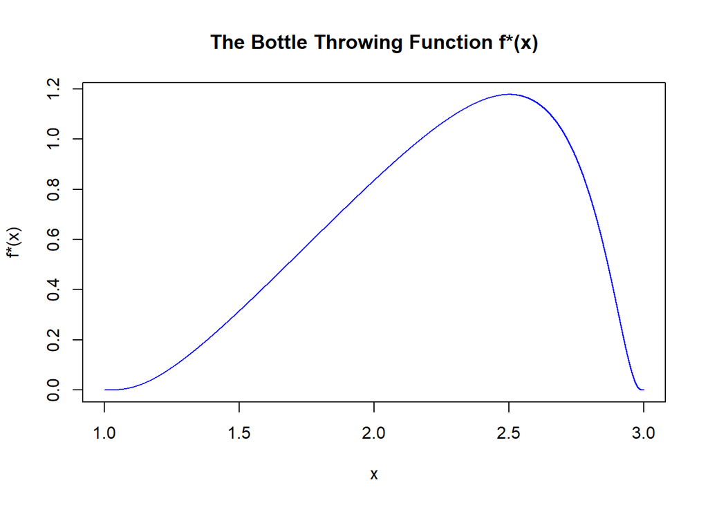

```r
#define interval
x<-seq(1+(10^(-6)),3-(10^(-6)),10^-6)
#plot x against f*
plot(x, fstar(x),
main="The Bottle Throwing Function f*(x)",
ylab="f*(x)",
type="l",
col="blue")
```

A trapezium function $g_Y (x)$ with edge coordinates $(1,0),(2.2,0.8),(2.7,0.8),(3,0)$ has a shape similar to that of $f*_X (x)$ and is invertible as it is composed of straight lines:
$$g_Y (x)= \begin{cases}
\frac{2(x-1)}{3} & 1<x \leq 2.2 \\
0.8 & 2.2<x<2.7 \\
\frac{8(3-x)}{3} & 2.7 \leq x < 3 \\ 0 & otherwise
\end{cases}$$

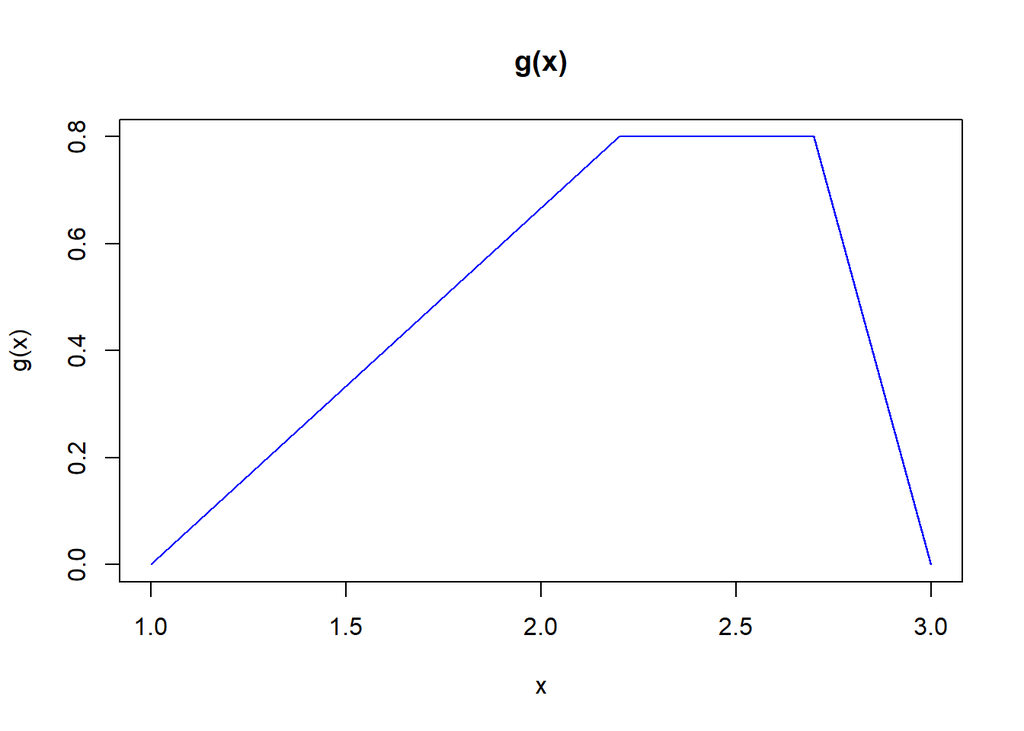

```r
#construct trapezium function
g <- function(y){
ifelse(y <= 2.2,(2/3)*(y-1),
ifelse(y <= 2.7, x <- 0.8
,8*(3-y)/3))
}
#define interval
x<-seq(1+(10^(-6)),3-(10^(-6)),10^-6)
#plot x against g
plot(x, g(x),
main="g(x)",
ylab="g(x)",
type="l",
col="blue")
```

As our trapezium function is piecewise, we must break down our g into its three components to find the maximum of $\frac{f*_X (x)}{g_Y (x)}$.

```r
x_1<-seq(1+10^-6,2.2,10^-6)
x_2<-seq(2.2,2.7,10^-6)
x_3<-seq(2.7,3-10^-6,10^-6)
#output sup_x (f*/g)
M=max(1.5*fstar(x_1)/(x_1-1),1.5*fstar(x_2)/1.2,1.5*fstar(x_3)/4*(3-x_3))
```

Our theoretical acceptance probability is defined as the area under our $f*_X (x)$ divided by our M: $\frac{\int f*_X (x) \mathrm{d}x}{M}$. Although our $f*_X (x)$, is not analytically integrable, R contains an inbuilt integrate function that calculates an approximation with numerical methods:

```r
integrate(fstar,1,3)
```

```
## 1.253314 with absolute error < 3e-06
```

```r
#calculate acceptance probability=area under f* divided by M
Acc_prob=1.253314/M
```

We shall clearly state the CDF $G_Y (x)$ below:
$$G_Y (x)= \begin{cases}
\frac{x^2-2x+1}{3} & 1<x \leq 2.2 \\
\frac{1.2x-1.92}{1.5} & 2.2<x<2.7 \\
\frac{(x-3)^2-0.75}{-0.75} & 2.7 \leq x < 3 \\ 0 & otherwise
\end{cases}$$